# Análise Bivariada

José Marcelo Alves

2023-11-30

## Introdução

Entender quais variáveis existem no seu data frame e como elas se relacionam é um dos principais objetivos em se realizar uma análise exploratória dos seus dados. Dedicar um bom tempo a essa atividade, realizando uma análise cuidadosa irá aumentar o seu conhecimento sobre seu objeto de estudo, facilitar a identificação de padrões ocultos e quem sabe até permitir que você identifique novas oportunidades de negócio.

Por isso, vale muito a pena entender como essas relações podem ser mensuradas e quais testes podemos fazer para validar as descobertas realizadas. Afinal, quem faz análise de dados busca gerar respostas a problemas de negócio com embassamento teórico que direcione a tomada de decisão. Achismos de uma forma geral não tem nada a ver com o nosso dia a dia.

Vamos dividir nossa análise bivariada em três formas distintas. Baseado no tipo de dados que estamos trabalhando a análise poderá envolver:

1. Uma variável categórica x outra variável categórica
2. Uma variável numérica x outra variável numérica
3. Uma variável categórica x outra variável numérica

Vamos utilizar um data frame fictício de imóveis. Abaixo temos uma amostra do mesmo:

```
## 'data.frame':    561 obs. of  9 variables:
##  $ ID_IMOVEL         : int  1 2 3 4 5 6 7 8 9 10 ...
##  $ BAIRRO_IMOVEL     : chr  "Santa Rosa" "Santa Rosa" "Santa Rosa" "Recanto Mar" ...
##  $ METRAGEM          : int  140 90 130 50 70 110 90 240 210 70 ...
##  $ TIPO_IMOVEL       : chr  "Apartamento" "Apartamento" "Casa" "Apartamento" ...
##  $ VALOR_VENDA       : int  517000 427000 558000 354000 416000 468000 436000 509000 692000 395000 ...
##  $ INCIDENCIA_LUZ    : chr  "Pouca" "Pouca" "Pouca" "Pouca" ...
##  $ VAGAS_GARAGEM     : int  2 2 5 2 NA NA NA 1 4 2 ...
##  $ FLUXO_VEICULOS    : chr  "Intenso" "Intermediário" "Baixo" "Intenso" ...
##  $ COMERCIOS_RAIO_1KM: int  19 13 11 NA 26 27 18 13 24 31 ...
```

## 01 - Uma variável categórica x outra variável categórica

Vamos iniciar nossa análise tentando compreender se existe alguma relação entre o tipo de imóvel (Casa ou Apartamento) e a incidência de luz (nenhuma, pouca ou muita).

Ambas as variáveis são categóricas, sendo a primeira uma variável categórica nominal e a segunda uma variável categórica ordinal.

Podemos aproveitar que temos esse entedimento e “ajudar” o R a lidar com essa informação, definindo qual a ordem de mensuração desta variável categórica ordinal:

```r
dados$INCIDENCIA_LUZ <- factor(dados$INCIDENCIA_LUZ, order = TRUE,
                               levels = c("Nenhuma", "Pouca", "Muita"))
```

Agora podemos criar uma tabela de contingêcia envolvendo estas duas variáveis. A mesma representa os valores observados para as duas variáveis em estudo e nos traz uma primeira ideia da volumetria envolvida.

```r
tabela_contingencia <- table(dados$TIPO_IMOVEL, dados$INCIDENCIA_LUZ)
tabela_contingencia
```

```
##
##               Nenhuma Pouca Muita
##   Apartamento     105   106   112
##   Casa             50    81   107
```

Também podemos avaliar as proporções envolvidas totalizando os dados por linha:

```r
prop.table(tabela_contingencia, margin = 1)
```

```
##
##                 Nenhuma     Pouca     Muita
##   Apartamento 0.3250774 0.3281734 0.3467492
##   Casa        0.2100840 0.3403361 0.4495798
```

Ou fazer a mesma análise, só que agora totalizando os dados por coluna:

```r
prop.table(tabela_contingencia, margin = 2)
```

```
##
##                 Nenhuma     Pouca     Muita
##   Apartamento 0.6774194 0.5668449 0.5114155
##   Casa        0.3225806 0.4331551 0.4885845
```

Aparentemente podemos dizer que existe uma proporção maior de apartamentos com nenhuma incidência de luz e uma proporção maior de casas com muita incidência de luz solar. A grande questão é: essa análise é realmente efetiva? Existe alguma forma de afirmar com um nível de significância estatístico relevante que essa relação é verdadeira?

A resposta é sim! Através do teste qui-quadrado podemos comparar o valor observado e o valor esperado de duas variáveis categóricas. Quanto mais as frequências observadas divergirem das frequências esperadas maior será a estatística do teste do qui-quadrado e maior será a correlação entre as duas variáveis.

O resultado do nosso teste qui-quadrado retorna:

```r
chisq <- chisq.test(tabela_contingencia)
chisq
```

```
##
##  Pearson's Chi-squared test
##
## data:  tabela_contingencia
## X-squared = 10.331, df = 2, p-value = 0.00571
```

Devemos entender o teste qui-quadrado como um teste de hipótese onde:

1. Ho: as variáveis são independentes (não existe relação entre elas)
2. Ha: as variáveis são dependentes (existe uma relação entre as mesmas)

A um nível de significância de 0,05 podemos afirmar que existe uma relação entre as variáveis estudadas. O nível de significância, ou alfa, é a probabilidade de rejeitarmos a hipótese nula (Ho) quando ela é verdadeira.

Como o valor-p resultante do teste qui-quadrado é menor que alfa (0,00571 < 0,05) rejeitamos a hipótese nula e assumimos que existe uma dependência entre as variáveis.

Os resíduos (ou resíduos de Pearson) retornam as variáveis que mais contribuem para para o resultado da estatística de teste qui-quadrado:

```r
round(chisq$residuals, 3)
```

```
##
##               Nenhuma  Pouca  Muita
##   Apartamento   1.668 -0.161 -1.255
##   Casa         -1.943  0.187  1.462
```

Podemos também analisar graficamente os resíduos:

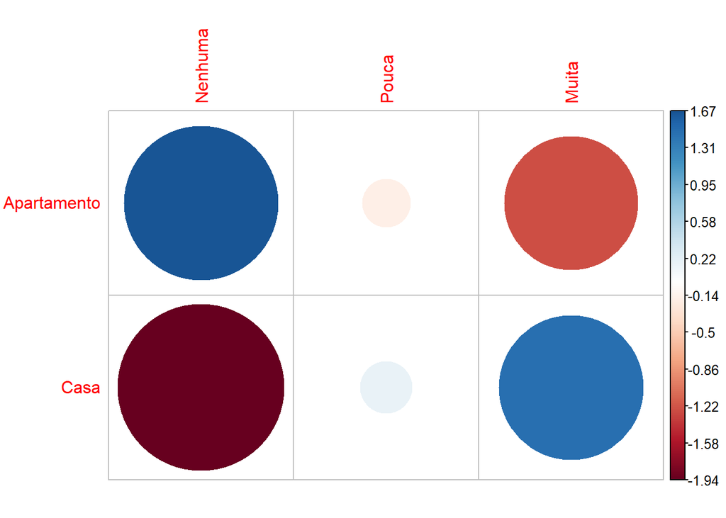

```r
corrplot(chisq$residuals, is.cor = FALSE)
```

Por fim, podemos avaliar a contribuição percentual de cada variável dentro da relação estudada:

```r
contrib <- 100*chisq$residuals^2/chisq$statistic
round(contrib, 3)
```

```
##
##               Nenhuma  Pouca  Muita
##   Apartamento  26.932  0.250 15.242
##   Casa         36.551  0.339 20.686
```

Por hoje paramos por aqui. Em outros artigos iremos estudar a análise bivariada entre uma variável númerica x outra variável numérica e por fim a análise bivariada entre uma variável categórica x outra variável numérica.

Os pacotes utilizados para realizar as análises deste artigo foram: DescTools, corrplot além de comandos do R base.